# Strings

MGinorio

## Character Manipulation & Data Processing

#### STRINGS - You can create strings with either single quotes or double quotes. Unlike other languages, there is no difference in behaviour. I recommend always using “, unless you want to create a string that contains multiple”.

#### DATES -Always use the simplest possible data type that works for your needs. That means if you can use a date instead of a date-time, you should. Date-times are substantially more complicated because of the need to handle time zones.

## Implementation

#### String Manipulation with string:: The string package provides a set of internally consistent tools for working with character strings, i.e sequences of characters surrounded by quotation marks

## Results

### Overview

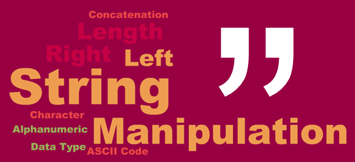

String Manipulation

```r
url.show("https://fivethirtyeight.com/features/the-economic-guide-to-picking-a-college-major/")
```

### Packages

```r
#Packages used

library(tidytext)
library(DT)
library(tm)
library(tidyverse)
library(stringr)
```

### 1.- Str_detect

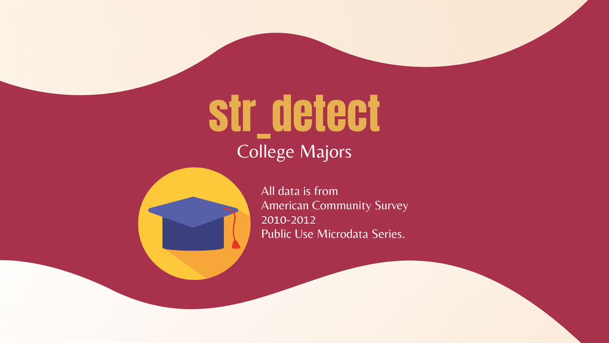

```r
college_majors <-read.csv("https://raw.githubusercontent.com/fivethirtyeight/data/master/college-majors/majors-list.csv")

glimpse(college_majors)
```

```
## Rows: 174
## Columns: 3
## $ FOD1P          <chr> "1100", "1101", "1102", "1103", "1104", "1105", "110...
## $ Major          <chr> "GENERAL AGRICULTURE", "AGRICULTURE PRODUCTION AND M...
## $ Major_Category <chr> "Agriculture & Natural Resources", "Agriculture & Na...
```

```r
data_majors <- str_detect(college_majors$Major, fixed("DATA"))
college_majors[data_majors, ]
```

```
##    FOD1P                                    Major          Major_Category
## 52  2101 COMPUTER PROGRAMMING AND DATA PROCESSING Computers & Mathematics
```

###### There is only one result that contains “DATA” = 2101

```r
stats_majors <- str_detect(college_majors$Major, fixed("STATISTICS"))
college_majors[stats_majors, ]
```

```
##    FOD1P                                         Major          Major_Category
## 44  6212 MANAGEMENT INFORMATION SYSTEMS AND STATISTICS                Business
## 59  3702               STATISTICS AND DECISION SCIENCE Computers & Mathematics
```

### 2.- String_extract

###### 2.1 Fruits

Create Produce List for Next Week

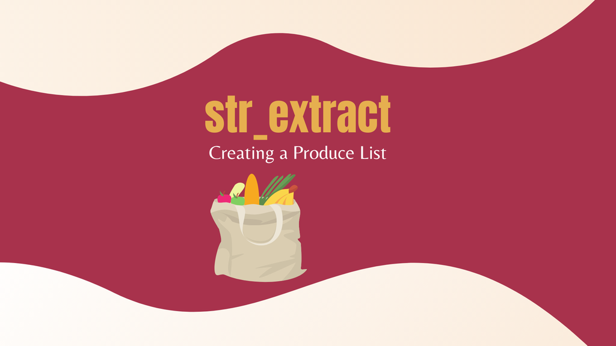

String Manipulation

[1] “bell pepper” “bilberry” “blackberry” “blood orange”

[5] “blueberry” “cantaloupe” “chili pepper” “cloudberry”

[9] “elderberry” “lime” “lychee” “mulberry”

[13] “olive” “salal berry”

Into a format like this:

c(“bell pepper”, “bilberry”, “blackberry”, “blood orange”, “blueberry”, “cantaloupe”, “chili pepper”, “cloudberry”, “elderberry”, “lime”, “lychee”, “mulberry”, “olive”, “salal berry”)

```r
str_1 = c("bell pepper", "bilberry", "blackberry", "blood orange", "bllueberry")
str_2 = c("blueberry", "cantaloupe", "chili pepper", "cloudberry")
str_3 = c("elderberry","lime","lychee","mulberry")
str_4 = c("olive", "salad berry")

fruit_list = c(str_1, str_2, str_3, str_4)
fruit_list
```

```
##  [1] "bell pepper"  "bilberry"     "blackberry"   "blood orange" "bllueberry"
##  [6] "blueberry"    "cantaloupe"   "chili pepper" "cloudberry"   "elderberry"
## [11] "lime"         "lychee"       "mulberry"     "olive"        "salad berry"
```

### 3.- String Expressions

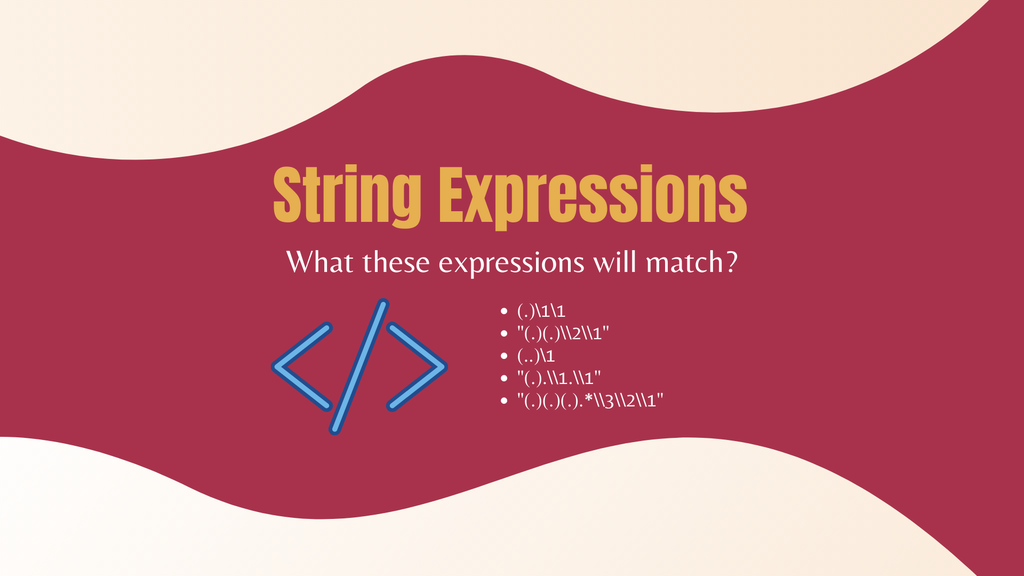

String Manipulation

###### Expressions

(.)\1\1

This expression refers to groups - () - we use parenthesis to set precedent (order of evaluation) in this case.

“(.)(.)\2\1”

```r
string_1 <- c("abba", "aaabbb","aaabbb", "abba", "bbaabbaa")
string_1 %>%
  str_detect(pattern = "(a)(b)\\2\\1")
```

```
## [1]  TRUE FALSE FALSE  TRUE  TRUE
```

(..)\1

This will search for two characters, repeated once, like “mama” or “5656”. The correct expression would be “(..)\1”.

(.).\1.\1"

"(.)(.)(.).*\3\2\1"

This will construct a set of characters that begin and end with the same three characters, except the second instance is reversed, like “racecar” or “12378724321”.

### 4.- Construct

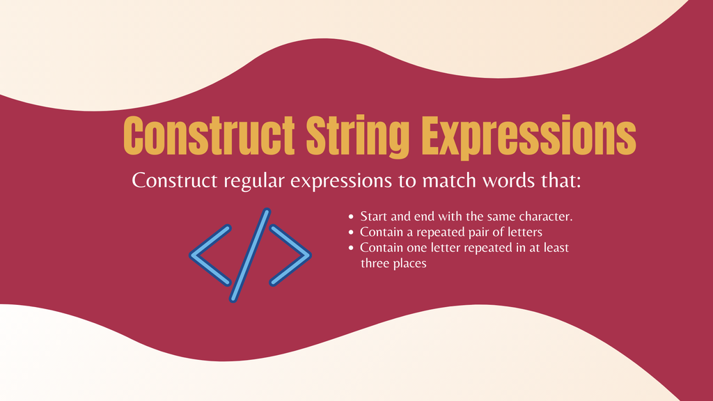

#### Strings #### Construct regular expressions to match words that:

```r
str_bring <- function(string, pattern) {
  string[str_detect(string, pattern)]
}
```

```r
str_bring(fruit_list, "(.).*\\1$")
```

```
## [1] "lychee"
```

#### Contain a repeated pair of letters (e.g. “church” contains “ch” repeated twice.)

```r
str_subset(fruit_list, "([A-Za-z][A-Za-z]).*\\1")
```

```
## [1] "bell pepper"  "chili pepper" "elderberry"
```

#### Contain one letter repeated in at least three places (e.g. “eleven” contains three “e”s.)

```r
str_subset(fruit_list, "([a-z]).*\\1.*\\1")
```

```
## [1] "bell pepper"  "blood orange" "chili pepper" "elderberry"
```